# Act Report

## Analysis and Insights

#### Most popular dog name

Analyzing this report comes with some limitation such as a large amount of unnamed dogs shown as none.

Using the value counts of name column i was able to get this analysis done, it shows the name "Cooper" as the most popular name, followed closely by "Charlie", "Oliver", "Koda' and "Sadie" while ignoring the none values which represents names with no records in our dataset.

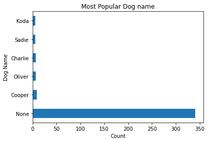

#### Most popular dog breed

From my analysis, using the value counts recorded in our combined dataset the "Golden Retriever" as the most popular dog breed, having the highest value counts of 117, followed by "pembroke", "Labrado Retriever", "chihuahua' et al with 77, 72 and 50 respectively, please refer to the image below for more insight.

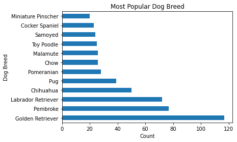

A Golden Retriever named "Stuart"

[figure not shown]

#### Correlation between the retweet count and favorite count

Correlation in this sense is a bivariate analysis that measures the strength of association between two variables and the direction of the relationship. Here the correlation shows a very strong positive correlation. Please, see image below for more insight.

Using this correlation between this two series, it would enabled me to work with both series together to further analyze our dataset going forward.

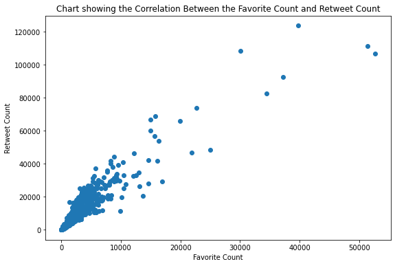

### Limitations

Due to an incomplete data gathered as a result of deleted tweets, tweets without images, et all, there could/would be changes to this insights should you also choose to make an analyses and visualization of this gathered files.